# HIV Treated vs Control

Guannan Shen

April 28, 2019

```
## [1] "/home/guanshim/Documents/gitlab/Cario_RNASeq_Microbiom_Inte/DataRaw/interferome"
```

# 1 Data Preprocessing

15 HIV-infected-treated donors vs. 11 healthy controls.

Filtering was applied. The inclusion criteria is the gene must have a total counts (sum up all samples) more than or equal to the number of samples times 5.

```
## [1] 42995    29
```

```
## [1] 19454    29
```

```
## [1] 19454    26
```

```
## [1] 0
```

```
## [1] 0
```

```
## [1] "size Factors of DESeq2"
```

```
##     Dys273     Dys458     TR1310     TR1407     TR1411     TR1413
## 0.79789780 0.99969433 0.50437187 0.97681439 1.21260872 0.67785014
##     TR1414     TR1441     TR1465     TR1470     TR1547     TR1540
## 1.27849108 1.36496878 3.05215853 1.07306093 1.55651157 2.39378345
##     TR1543     TR1549     TR1551     TR1584     TR1609     TR1624
## 0.84006231 1.31408657 0.73645014 1.28621315 0.94034702 0.63233051
##     TR1667     TR1745     TR1750     TR1761     TR1762     TR1767
## 1.65986127 1.09085212 0.02102718 1.32351536 1.71885382 1.30772301
##     TR1772     TR1778
## 1.33486927 1.92295971
```

```
## [1] "Scaling Factors of edgeR"
```

```
##        group lib.size norm.factors
## Dys273     1  9911221    1.0279785
## Dys458     1 12864304    0.9724361
## TR1310     1  5812422    1.1712279
## TR1407     1 12343180    0.9874273
## TR1411     1 15397860    0.9944690
## TR1413     1  8250381    1.0415633
## TR1414     1 16792358    0.9421498
## TR1441     1 18627946    0.9140060
## TR1465     1 37806975    1.0178661
## TR1470     1 13606210    0.9860379
## TR1547     1 18822910    1.0530744
## TR1540     2 29118046    1.0572315
## TR1543     2 10517275    1.0127317
## TR1549     2 17635931    0.9082841
## TR1551     2  9410478    0.9782783
## TR1584     2 16426100    0.9868844
## TR1609     2 12676127    0.9344833
## TR1624     2  8479498    0.9444599
## TR1667     2 20695728    1.0203244
## TR1745     2 13343289    1.0523453
## TR1750     2   246053    1.1471863
## TR1761     2 16905800    0.9941672
## TR1762     2 22614419    0.9653455
## TR1767     2 17213442    0.9589025
## TR1772     2 16863025    1.0086283
## TR1778     2 24971043    0.9684355
```

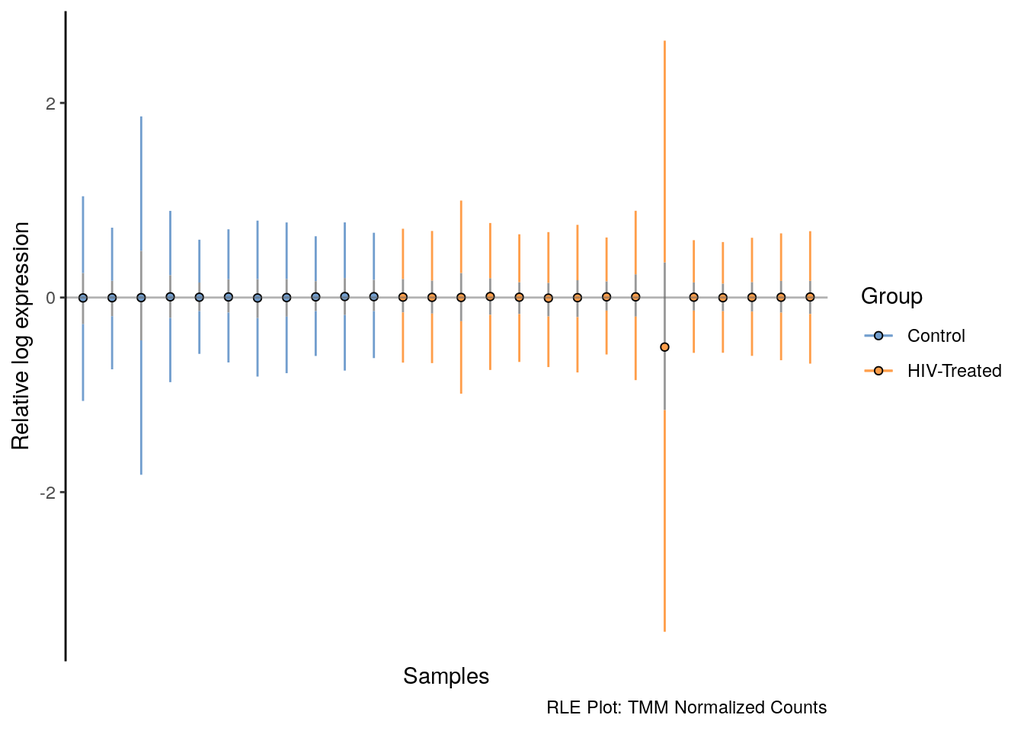

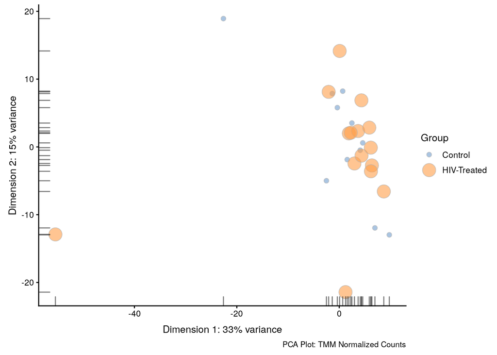

```
## character(0)
```

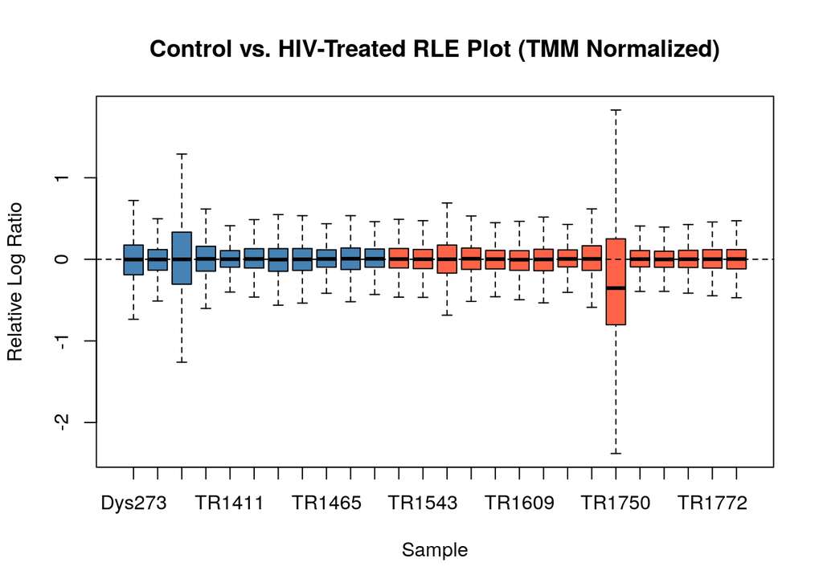

```
## [1] "TR1750"
```

```
## [1] 19454    25
```

```
## [1] "size Factors of DESeq2"
```

```
##    Dys273    Dys458    TR1310    TR1407    TR1411    TR1413    TR1414
## 0.6869759 0.8450170 0.4554122 0.8321846 1.0419117 0.5847781 1.0728487
##    TR1441    TR1465    TR1470    TR1547    TR1540    TR1543    TR1549
## 1.1539470 2.6279787 0.9204808 1.3536915 2.0815888 0.7221778 1.0914246
##    TR1551    TR1584    TR1609    TR1624    TR1667    TR1745    TR1761
## 0.6319997 1.1001928 0.7963843 0.5398470 1.4405524 0.9547214 1.1391456
##    TR1762    TR1767    TR1772    TR1778
## 1.4734891 1.1190398 1.1496630 1.6463417
```

```
## [1] "Scaling Factors of edgeR"
```

```
##        group lib.size norm.factors
## Dys273     1  9911221    1.0336402
## Dys458     1 12864304    0.9777919
## TR1310     1  5812422    1.1776785
## TR1407     1 12343180    0.9928657
## TR1411     1 15397860    0.9999462
## TR1413     1  8250381    1.0472998
## TR1414     1 16792358    0.9473388
## TR1441     1 18627946    0.9190400
## TR1465     1 37806975    1.0234721
## TR1470     1 13606210    0.9914687
## TR1547     1 18822910    1.0588744
## TR1540     2 29118046    1.0630543
## TR1543     2 10517275    1.0183094
## TR1549     2 17635931    0.9132866
## TR1551     2  9410478    0.9836662
## TR1584     2 16426100    0.9923198
## TR1609     2 12676127    0.9396301
## TR1624     2  8479498    0.9496616
## TR1667     2 20695728    1.0259439
## TR1745     2 13343289    1.0581412
## TR1761     2 16905800    0.9996427
## TR1762     2 22614419    0.9706623
## TR1767     2 17213442    0.9641837
## TR1772     2 16863025    1.0141834
## TR1778     2 24971043    0.9737693
```

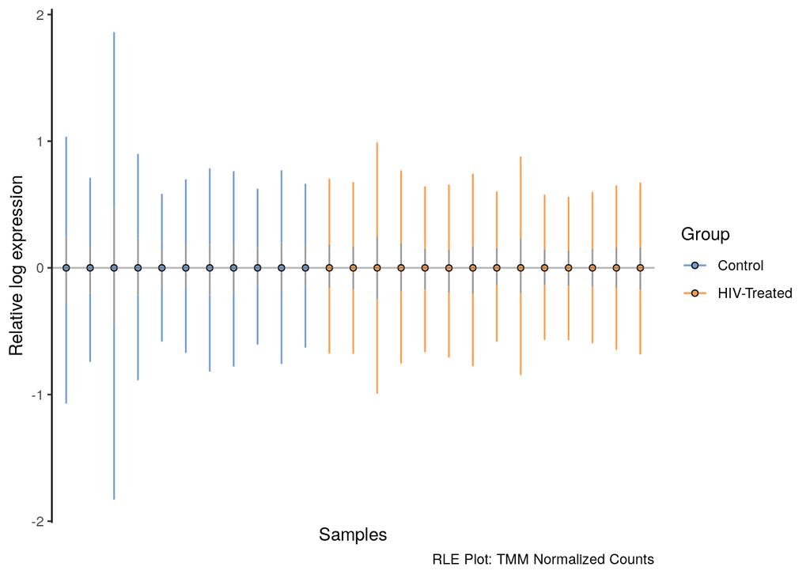

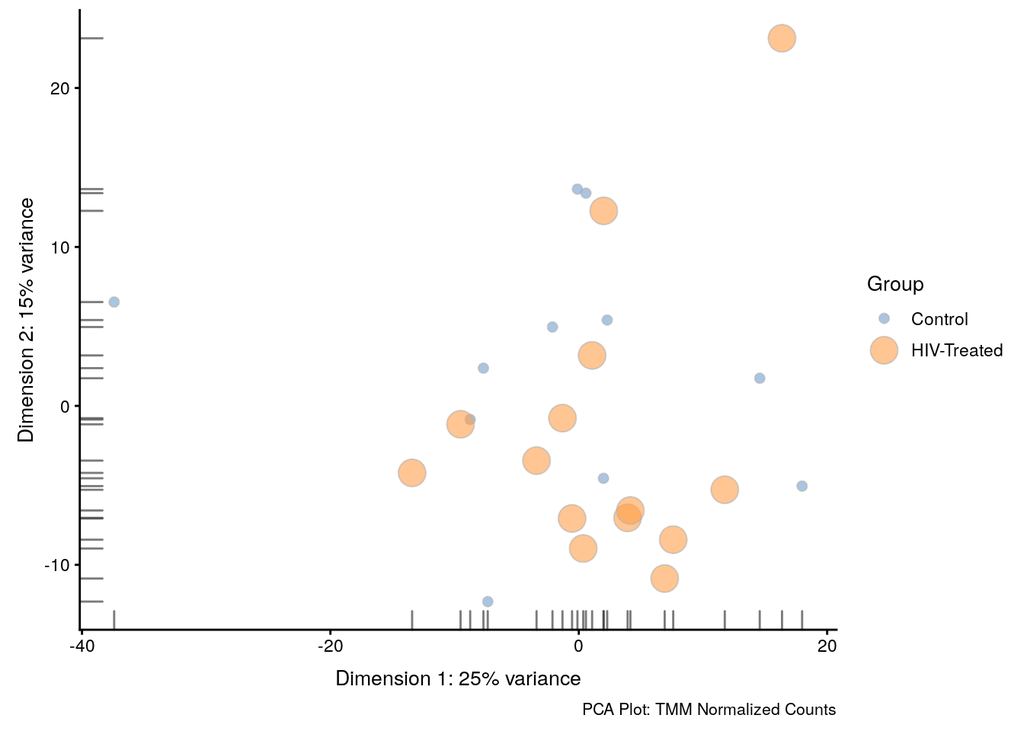

From the scaling factor, we can tell the between-samples variance is samller compared with the HIV-untreated dataset. For the previous dataset, the more the size factors differ, the more residual dependence of the variance on the mean will be found in the transformed data. **rlog** is a transformation which can perform better in these cases.

For this dataset, a variance stabilizing transformation, **vst** should be more proper.

varianceStabilizingTransformation(object, blind = FALSE, fitType = “parametric”)

getVarianceStabilizedData(object)

From the quality control plots, “TR1750” was deleted.

```r
# make sure y is the object from edger DE analysis of edger
y <- estimateDisp(y)
```

```
## Design matrix not provided. Switch to the classic mode.
```

```r
et <- exactTest(y, pair = 1:2)
dim(et)
```

```
## [1] 19454     3
```

```r
y$samples
```

```
##        group lib.size norm.factors
## Dys273     1  9911221    1.0336402
## Dys458     1 12864304    0.9777919
## TR1310     1  5812422    1.1776785
## TR1407     1 12343180    0.9928657
## TR1411     1 15397860    0.9999462
## TR1413     1  8250381    1.0472998
## TR1414     1 16792358    0.9473388
## TR1441     1 18627946    0.9190400
## TR1465     1 37806975    1.0234721
## TR1470     1 13606210    0.9914687
## TR1547     1 18822910    1.0588744
## TR1540     2 29118046    1.0630543
## TR1543     2 10517275    1.0183094
## TR1549     2 17635931    0.9132866
## TR1551     2  9410478    0.9836662
## TR1584     2 16426100    0.9923198
## TR1609     2 12676127    0.9396301
## TR1624     2  8479498    0.9496616
## TR1667     2 20695728    1.0259439
## TR1745     2 13343289    1.0581412
## TR1761     2 16905800    0.9996427
## TR1762     2 22614419    0.9706623
## TR1767     2 17213442    0.9641837
## TR1772     2 16863025    1.0141834
## TR1778     2 24971043    0.9737693
```

```r
### results
topTags(et, n = 10, adjust.method = "BH")
```

```
## Comparison of groups:  2-1
##                         logFC   logCPM       PValue         FDR
## ENSG00000231167.3  -2.9518127 2.727191 6.477737e-08 0.001260179
## ENSG00000264229.1  -1.3306471 4.892415 3.156568e-07 0.003070393
## ENSG00000212464.1  -1.4890820 4.936972 6.099873e-07 0.003955564
## ENSG00000263934.4  -3.2178108 3.242671 1.366898e-06 0.006647910
## ENSG00000137312.14 -0.4264807 4.998530 2.533288e-06 0.008972761
## ENSG00000141510.16 -0.5328804 4.375874 2.838660e-06 0.008972761
## ENSG00000130731.15 -0.5509919 3.294090 3.228607e-06 0.008972761
## ENSG00000090615.13  0.3694307 8.212854 3.874128e-06 0.009420910
## ENSG00000197622.12 -0.5018421 4.042027 6.762614e-06 0.014617766
## ENSG00000163159.11 -0.5132554 4.176582 8.345280e-06 0.014750056
```

```r
head(et$table)
```

```
##                          logFC     logCPM    PValue
## ENSG00000148584.14  0.04733598  6.9500627 0.7495238
## ENSG00000175899.14  0.25512082  5.7055553 0.1581423
## ENSG00000256069.7  -0.32643398 -0.9379489 0.3296096
## ENSG00000128274.15  0.16115790  1.4825421 0.3881555
## ENSG00000094914.12 -0.02996589  2.4542705 0.8205141
## ENSG00000081760.16  0.13515016  5.6418913 0.2857115
```

```r
et$comparison
```

```
## [1] "1" "2"
```

```r
## summary results
summary(decideTests(et, p.value = 0.05, lfc = 0))
```

```
##          2-1
## Down      25
## NotSig 19424
## Up         5
```

```r
# paste(1706+ 2540, 'genes with FDR 0.05')

summary(decideTests(et, p.value = 0.05, lfc = 1))
```

```
##          2-1
## Down      10
## NotSig 19444
## Up         0
```

```r
# paste(157 + 680, 'genes with FDR 0.05')

summary(decideTests(et, p.value = 0.05, lfc = 2))
```

```
##          2-1
## Down       3
## NotSig 19451
## Up         0
```

```r
########## deleted ###########
"TR1750"
```

```
## [1] "TR1750"
```

```r
## import genes lists
isgs <- as.data.frame(read.delim("~/Documents/gitlab/Cario_RNASeq_Microbiom_Inte/DataRaw/coreISG252"))
dim(isgs)
```

```
## [1] 252   2
```

```r
genesbeta <- as.data.frame(read.delim("~/Documents/gitlab/Cario_RNASeq_Microbiom_Inte/DataRaw/genesbeta424"))
dim(genesbeta)
```

```
## [1] 424   2
```

```r
sig_res <- as.data.frame(topTags(et, n = 30, adjust.method = "BH")[[1]])

write.xlsx(sig_res, "~/Documents/gitlab/Cario_RNASeq_Microbiom_Inte/DataProcessed/interferome/treated/DE_results_treated.xlsx",
    sheetName = "DE Results Treated")
sig_res_format <- sig_res %>% data.frame() %>% rownames_to_column("Gene_ID")

merge(sig_res_format, isgs, by = "Gene_ID")
```

```
## [1] Gene_ID logFC   logCPM  PValue  FDR     Symbol
## <0 rows> (or 0-length row.names)
```

```r
merge(sig_res_format, genesbeta, by = "Gene_ID")
```

```
## [1] Gene_ID logFC   logCPM  PValue  FDR     Symbol
## <0 rows> (or 0-length row.names)
```

```r
merge(sig_res_format, cnts_fsym[, c(1, 2)], by = "Gene_ID") %>%
    dplyr::select(-Gene_ID) %>% dplyr::select(Symbol, everything()) %>%
    dplyr::arrange(PValue) %>% dplyr::mutate(Direction = ifelse(logFC >
    0, "Up in HIV", "Down in HIV")) %>% kable
```

| Symbol | logFC | logCPM | PValue | FDR | Direction |
| --- | --- | --- | --- | --- | --- |
| YBX1P2 | -2.9518127 | 2.7271906 | 1.00e-07 | 0.0012602 | Down in HIV |
| RNU4ATAC | -1.3306471 | 4.8924150 | 3.00e-07 | 0.0030704 | Down in HIV |
| SNORA12 | -1.4890820 | 4.9369719 | 6.00e-07 | 0.0039556 | Down in HIV |
| SNORD3A | -3.2178108 | 3.2426712 | 1.40e-06 | 0.0066479 | Down in HIV |
| FLOT1 | -0.4264807 | 4.9985299 | 2.50e-06 | 0.0089728 | Down in HIV |
| TP53 | -0.5328804 | 4.3758741 | 2.80e-06 | 0.0089728 | Down in HIV |
| C16orf13 | -0.5509919 | 3.2940896 | 3.20e-06 | 0.0089728 | Down in HIV |
| GOLGA3 | 0.3694307 | 8.2128538 | 3.90e-06 | 0.0094209 | Up in HIV |
| CDC42SE1 | -0.5018421 | 4.0420270 | 6.80e-06 | 0.0146178 | Down in HIV |
| VPS72 | -0.5132554 | 4.1765816 | 8.30e-06 | 0.0147501 | Down in HIV |
| APEX1 | -0.4582032 | 5.9791016 | 8.40e-06 | 0.0147501 | Down in HIV |
| HIST1H1E | -0.7399623 | 2.9516400 | 9.60e-06 | 0.0147501 | Down in HIV |
| MLLT6 | -0.6042437 | 6.6653715 | 1.07e-05 | 0.0147501 | Down in HIV |
| RP11-290F24.6 | 0.6510761 | 4.4827408 | 1.07e-05 | 0.0147501 | Up in HIV |
| ITPRIPL2 | -0.4471403 | 6.1805381 | 1.20e-05 | 0.0147501 | Down in HIV |
| EDRF1-AS1 | -1.7311074 | 0.1722422 | 1.21e-05 | 0.0147501 | Down in HIV |
| MAN2C1 | -1.0625679 | 3.3458093 | 1.57e-05 | 0.0180052 | Down in HIV |
| FLOT2 | -0.5142468 | 5.2612180 | 2.05e-05 | 0.0221365 | Down in HIV |
| CTD-2373H9.3 | -1.4020486 | -0.3876597 | 2.45e-05 | 0.0250536 | Down in HIV |
| RP11-1060J15.5 | 0.8105992 | 2.8293451 | 3.00e-05 | 0.0291992 | Up in HIV |
| RP3-522J7.7 | -1.8216759 | -0.0922535 | 4.48e-05 | 0.0400928 | Down in HIV |
| UBE2Z | -0.2881447 | 6.7015692 | 4.58e-05 | 0.0400928 | Down in HIV |
| RP11-848P1.4 | -4.9958517 | -0.4556851 | 4.75e-05 | 0.0400928 | Down in HIV |
| C11orf58 | -0.4022828 | 8.0082501 | 5.19e-05 | 0.0400928 | Down in HIV |
| HINT3 | -0.5035187 | 5.4364427 | 5.31e-05 | 0.0400928 | Down in HIV |
| RN7SL4P | -0.8283147 | 4.8490489 | 5.36e-05 | 0.0400928 | Down in HIV |
| ATF4 | 0.3291064 | 7.7700673 | 5.78e-05 | 0.0416384 | Up in HIV |
| LINC00854 | -1.1073419 | 1.5205470 | 6.22e-05 | 0.0432401 | Down in HIV |
| RP11-159N11.4 | 0.9154231 | 0.5829584 | 6.50e-05 | 0.0435934 | Up in HIV |
| NMT2 | -0.5552232 | 5.9698675 | 7.65e-05 | 0.0495841 | Down in HIV |

The DE analysis, only 30 out of 19454 genes are significantly altered between hiv-status.  
In terms of Healthy Controls vs. HIV-Infected:  
Comparison of groups: 2-1

[1] “1” “2”

```
     2-1
```

Down 1706

NotSig 15644

Up 2540

[1] “4246 genes with FDR 0.05”

```
     2-1
```

Down 157

NotSig 19053

Up 680

[1] “837 genes with FDR 0.05 and LogFC 1”

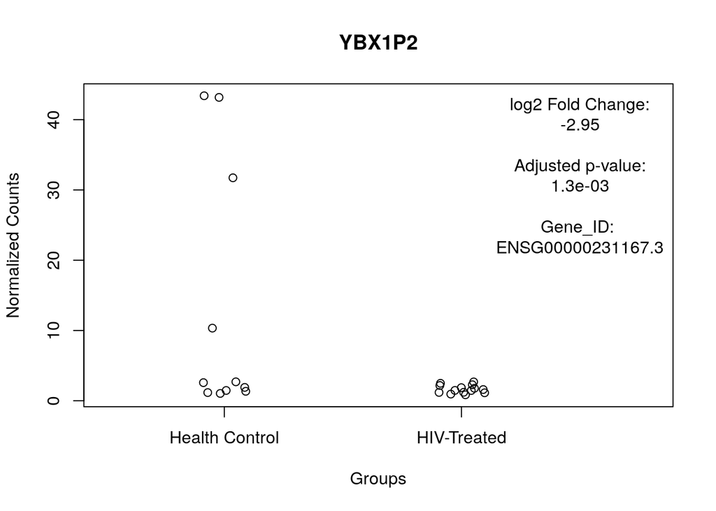

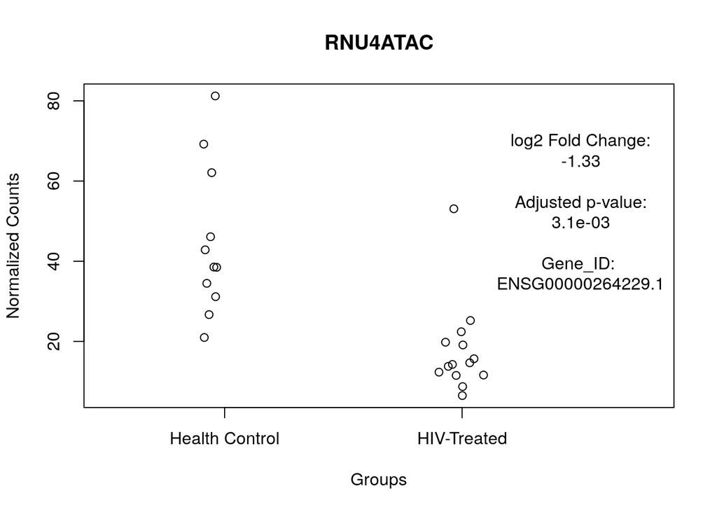

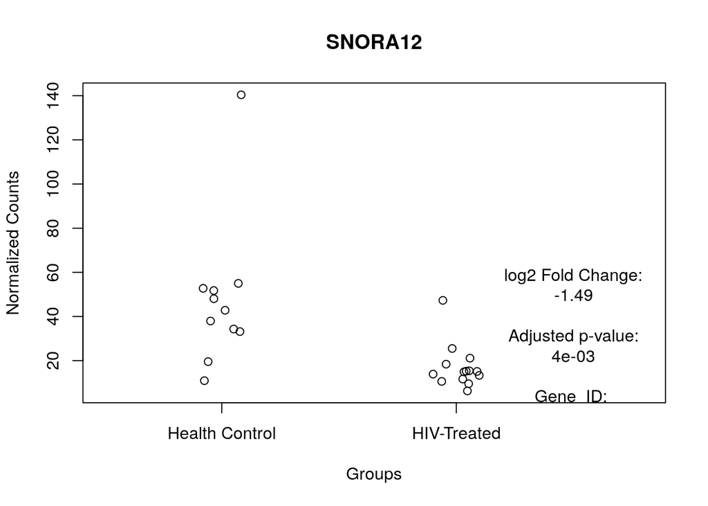

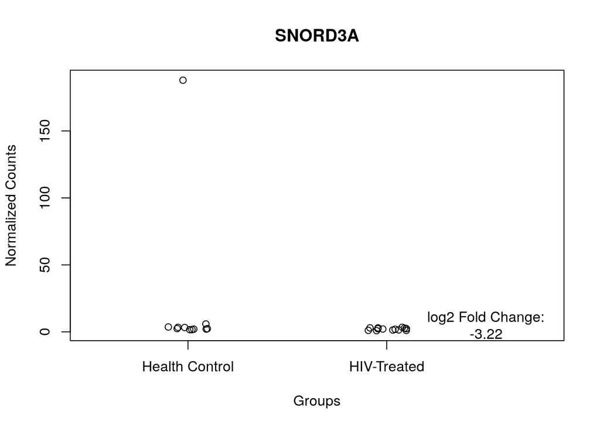

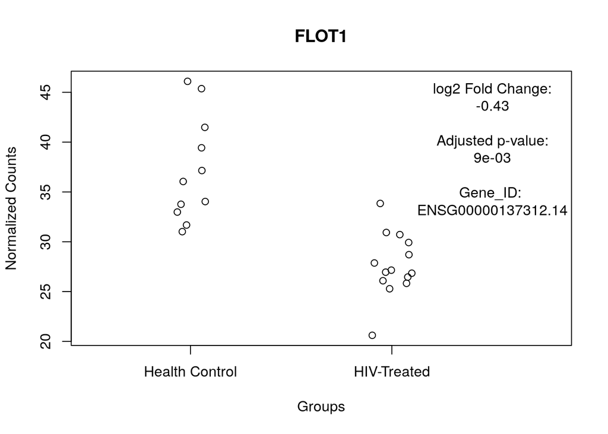

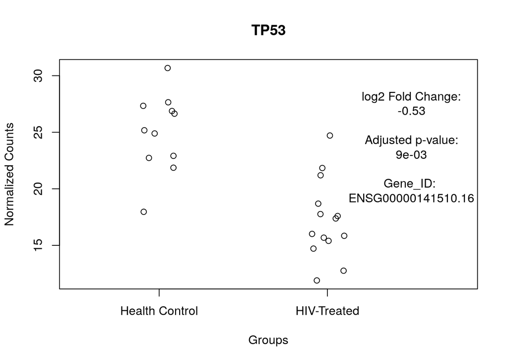

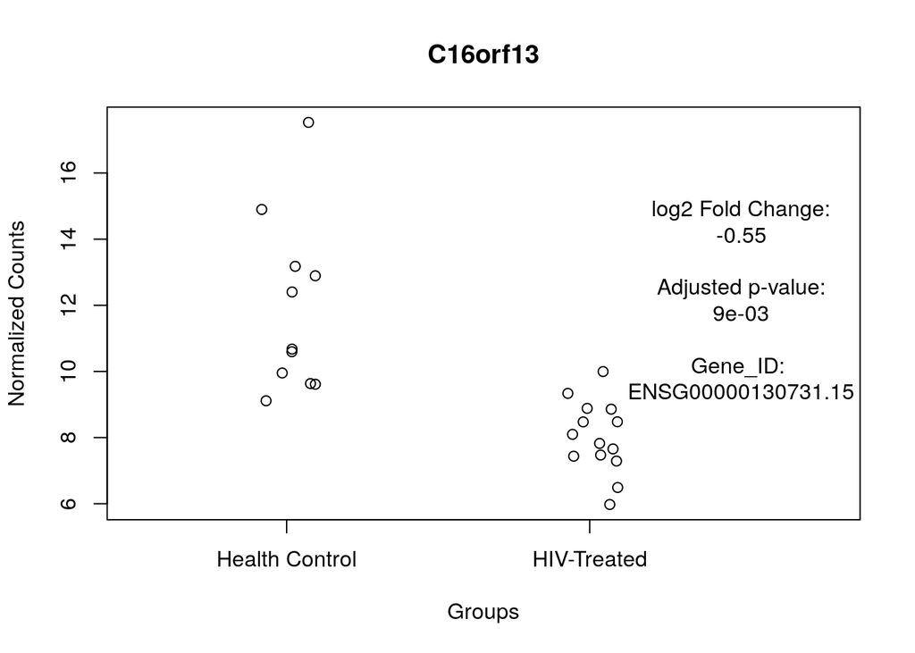

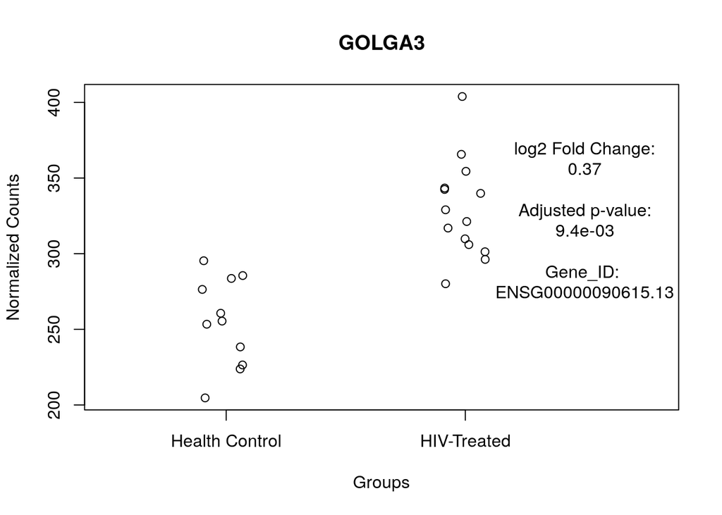

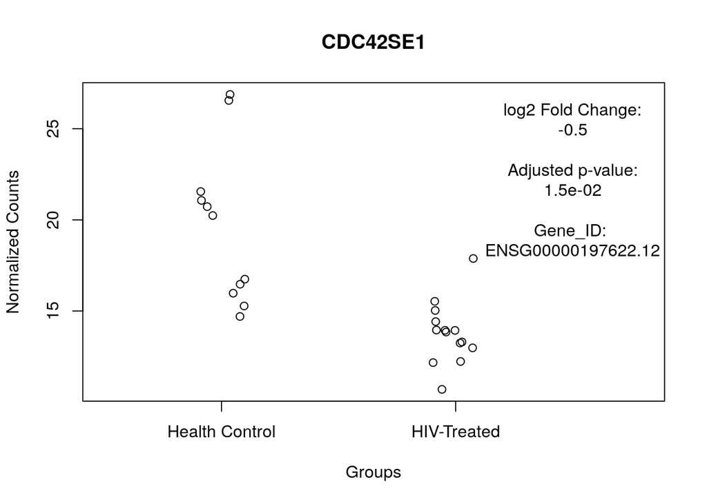

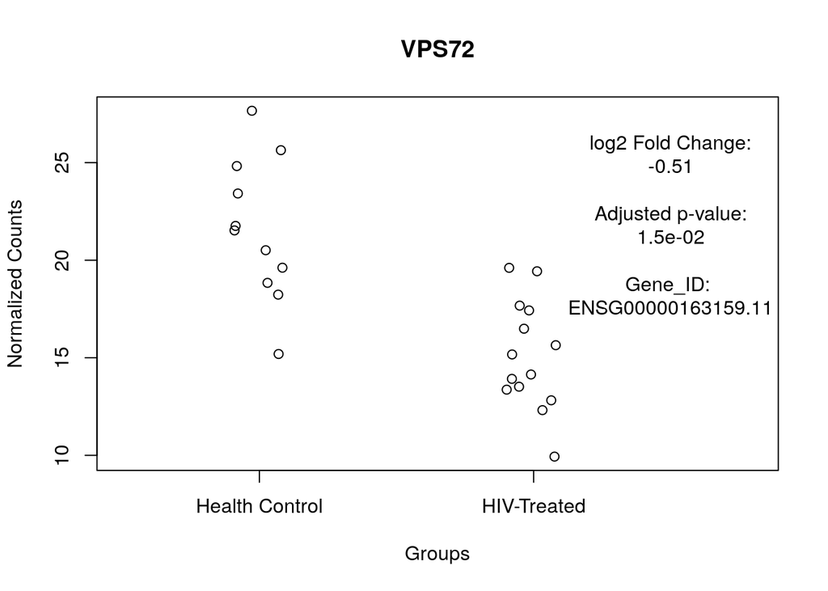

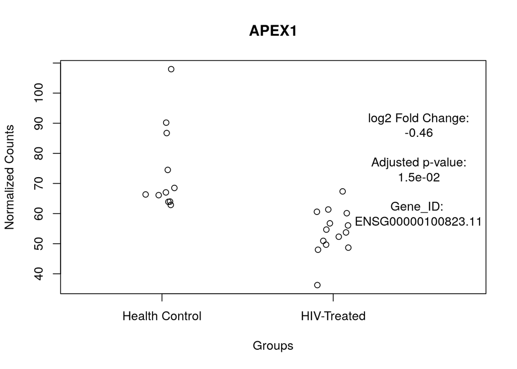

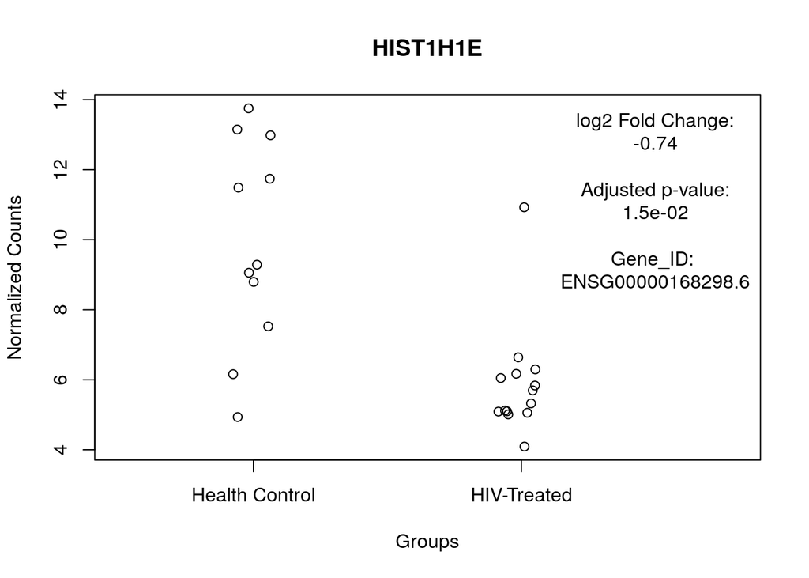

[18 more figures not shown]

```r
# all the results
res.edger <- et$table %>% dplyr::mutate(Symbol = cnts_fsym$Symbol,
    FDR = p.adjust(et$table$PValue, method = "BH"))
# label
group.plot <- factor(c(rep(1, 11), rep(2, 14)), labels = c("Health Control",
    "HIV-Treated"))
## use the # No. of genes in the cnts.edger matrix
sim_plotcounts <- function(genenumber) {
    plot(as.integer(group.plot) + runif(ncol(cnts.edger), -0.1,
        0.1), cnts.edger[genenumber, ], xlim = c(0.5, length(levels(group.plot)) +
        0.8), xaxt = "n", xlab = "Groups", ylab = "Normalized Counts",
        main = res.edger[genenumber, ]$Symbol)
    axis(1, at = seq_along(levels(group.plot)), levels(group.plot))
    ## pos below
    text(length(levels(group.plot)) + 0.5, stats::quantile(cnts.edger[genenumber,
        ], 0.95), paste("log2 Fold Change:", round(res.edger[genenumber,
        ]$logFC, 2), "", "Adjusted p-value:", format(res.edger[genenumber,
        ]$FDR, digits = 2, scientific = TRUE), "", "Gene_ID: ",
        rownames(cnts.edger)[genenumber], sep = "\n"), pos = 1)
}
## plot top 30
for (i in order(res.edger$PValue)[1:30]) {
    sim_plotcounts(i)
}
```

```r
## check the outlier
outliers <- c("SNORD3A", "SNORA12", "MLLT6", "NMT2", "MAN2C1",
    "EDRF1-AS1", "CTD-2373H9.3", "RP3-522J7.7", "RP11-848P1.4",
    "LINC00854")
# get the gennumber of outliers
out_number <- res.edger[order(res.edger$PValue)[1:30], ] %>%
    rownames_to_column("Num") %>% dplyr::filter(Symbol %in% outliers)
# get cnts especially for healthy controls
cnts_out <- cnts.edger[as.numeric(out_number$Num), 1:11] %>%
    as.data.frame()

#
out_id <- NULL
for (i in 1:nrow(cnts_out)) {
    out_id <- c(out_id, colnames(cnts_out)[cnts_out[i, ] == max(cnts_out[i,
        ])])
}
length(out_id)
```

```
## [1] 10
```

```r
out_id
```

```
##  [1] "TR1310" "TR1310" "TR1310" "TR1310" "TR1310" "TR1310" "TR1310"
##  [8] "TR1414" "TR1310" "TR1310"
```

```r
#
kable(cnts_out[, 1:7])
```

|  | Dys273 | Dys458 | TR1310 | TR1407 | TR1411 | TR1413 | TR1414 |
| --- | --- | --- | --- | --- | --- | --- | --- |
| ENSG00000212464.1 | 10.9325496 | 19.5570073 | 140.3910726 | 54.9974212 | 48.0612127 | 42.8209883 | 52.7405852 |
| ENSG00000263934.4 | 2.0498531 | 2.4645009 | 187.8698433 | 3.2639419 | 3.3772744 | 2.0831832 | 2.3887273 |
| ENSG00000275023.4 | 152.7628588 | 125.0535468 | 236.6634106 | 130.4760780 | 100.0192804 | 124.4123309 | 68.8330641 |
| ENSG00000236991.6 | 2.7331374 | 0.7950003 | 8.0348689 | 0.7343869 | 0.5845283 | 1.0415916 | 0.5028900 |
| ENSG00000140400.15 | 13.0800147 | 10.9710041 | 51.7153379 | 14.2797459 | 9.1576094 | 11.4575077 | 7.2290433 |
| ENSG00000279339.1 | 1.1713446 | 0.8745003 | 2.9217705 | 1.3871753 | 0.7144234 | 0.5786620 | 0.5657512 |
| ENSG00000279345.1 | 1.1713446 | 0.5565002 | 9.4957541 | 0.3263942 | 0.3247379 | 0.9258592 | 0.6914737 |
| ENSG00000266340.1 | 0.0976121 | 0.0000000 | 0.4382656 | 0.3263942 | 0.0000000 | 0.0000000 | 13.5151678 |
| ENSG00000236383.8 | 6.1495592 | 2.1465008 | 13.2940558 | 2.1215622 | 2.3381130 | 3.2405072 | 1.6972536 |
| ENSG00000152465.17 | 91.6577153 | 88.9605333 | 160.6973776 | 66.5844150 | 58.9074593 | 57.4032708 | 61.0382697 |

```r
paste("Basically, TR1310 is the outlier based on the grouped scattered plot")
```

```
## [1] "Basically, TR1310 is the outlier based on the grouped scattered plot"
```

# 2 Final Analysis

According to the quality control plots, “TR1750” in HIV-treated was deleted.  
According to the PCA plots and grouped scatter plots of top DE genes, “TR1310” in healthy controls should be deleted.

```r
# this one should be further deleted based on cnts_f_dele
which(rna.pid %in% "TR1310")
```

```
## [1] 3
```

```r
########## need to double check by the pca plots scater::plotPCA
########## ##################
paste("Before Deletion")
```

```
## [1] "Before Deletion"
```

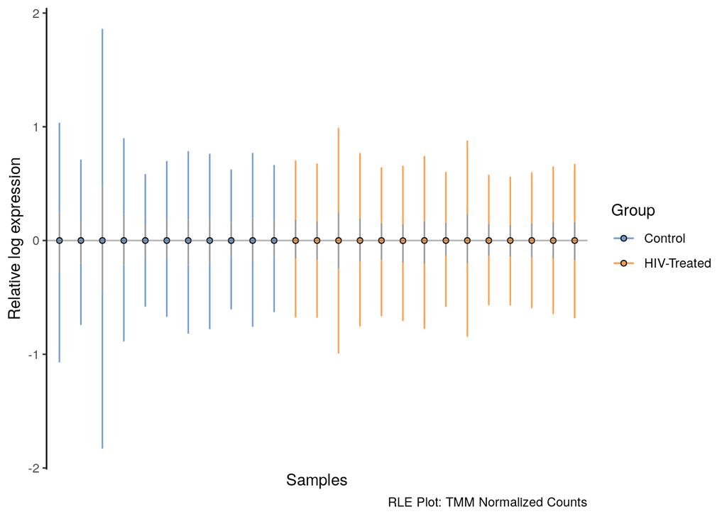

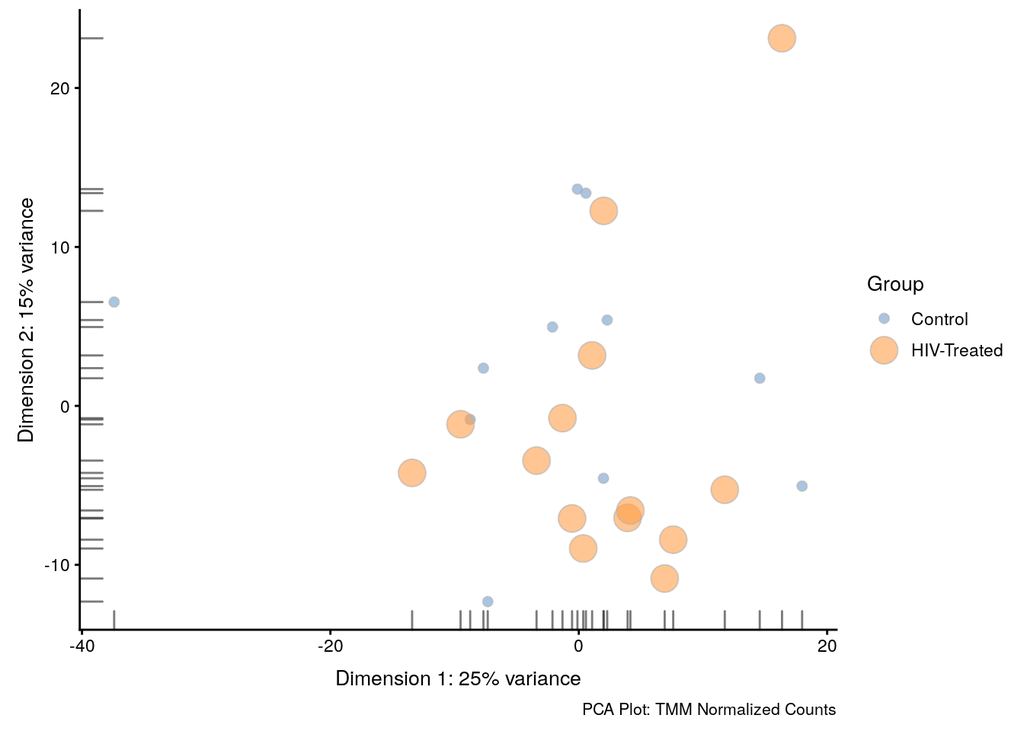

```r
for (i in 2) {
    j = cnts.list[[i]]
    ## using scater, start with an object
    example_sce <- SingleCellExperiment(assays = list(counts = j),
        colData = rna_info)
    ## RLE plots
    print(scater::plotRLE(example_sce, exprs_values = "counts",
        exprs_logged = FALSE, colour_by = "Group", style = "minimal") +
        scale_x_discrete("Samples", labels = rna.pid) + labs(caption = paste("RLE Plot:",
        cnts.names[i])))
    ## pca plots
    example_sce <- SingleCellExperiment(assays = list(logcounts = j),
        colData = rna_info)
    print(scater::plotPCA(example_sce, colour_by = "Group", size_by = "Group") +
        labs(caption = paste("PCA Plot:", cnts.names[i])))
}
```

```r
################## delete this one ####################
cnts_f_f <- cnts_f_dele[, -3]
dim(cnts_f_f)
```

```
## [1] 19454    24
```

```r
ctrl.id <- colnames(cnts_f_f)[1:10]
hiv.id <- colnames(cnts_f_f)[11:24]

rna.pid <- colnames(cnts_f_f)
pheno <- data.frame(pid = rna.pid, txt = as.factor(c(rep("Control",
    10), rep("HIV-Treated", 14))))
pheno$txt %<>% relevel("Control")

# using the function from EDASeq
set <- newSeqExpressionSet(as.matrix(cnts_f_f), phenoData = data.frame(condition = as.factor(pheno$txt),
    row.names = colnames(cnts_f_f)))

# edgeR TMM ############### edgeR object
group <- c(rep(1, 10), rep(2, 14))
y <- DGEList(counts = as.matrix(cnts_f_f), group = group)
## normalization
y <- calcNormFactors(y, method = "TMM")
paste("Scaling Factors of edgeR")
```

```
## [1] "Scaling Factors of edgeR"
```

```r
y$samples
```

```
##        group lib.size norm.factors
## Dys273     1  9911221    1.0330623
## Dys458     1 12864304    0.9738737
## TR1407     1 12343180    1.0147846
## TR1411     1 15397860    1.0058533
## TR1413     1  8250381    1.0496798
## TR1414     1 16792358    0.9601792
## TR1441     1 18627946    0.9338804
## TR1465     1 37806975    1.0210527
## TR1470     1 13606210    1.0069346
## TR1547     1 18822910    1.0698456
## TR1540     2 29118046    1.0564466
## TR1543     2 10517275    1.0222406
## TR1549     2 17635931    0.9404759
## TR1551     2  9410478    1.0009466
## TR1584     2 16426100    0.9980155
## TR1609     2 12676127    0.9435045
## TR1624     2  8479498    0.9507920
## TR1667     2 20695728    1.0316035
## TR1745     2 13343289    1.0603504
## TR1761     2 16905800    0.9963061
## TR1762     2 22614419    0.9684058
## TR1767     2 17213442    0.9743214
## TR1772     2 16863025    1.0200046
## TR1778     2 24971043    0.9852549
```

```r
# the TMM normalized Counts
cnts.edger <- edgeR::cpm(y)
cnts.TMM.id <- cnts.edger %>% as.data.frame() %>% rownames_to_column("Gene_ID")
sum(cnts.TMM.id$Gene_ID == cnts_fsym$Gene_ID)
```

```
## [1] 19454
```

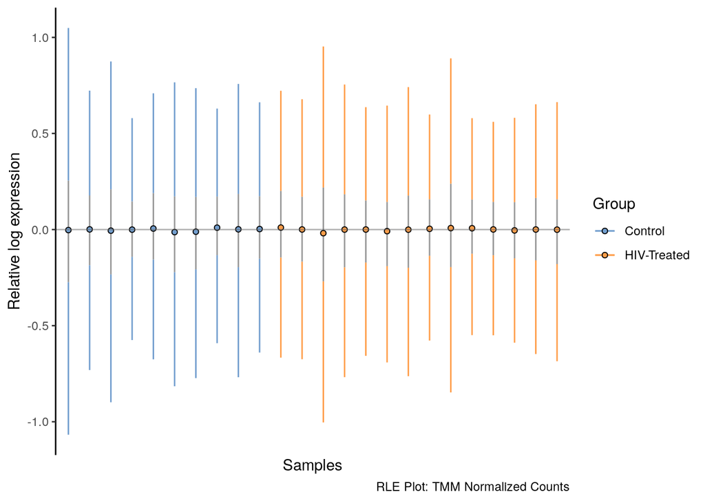

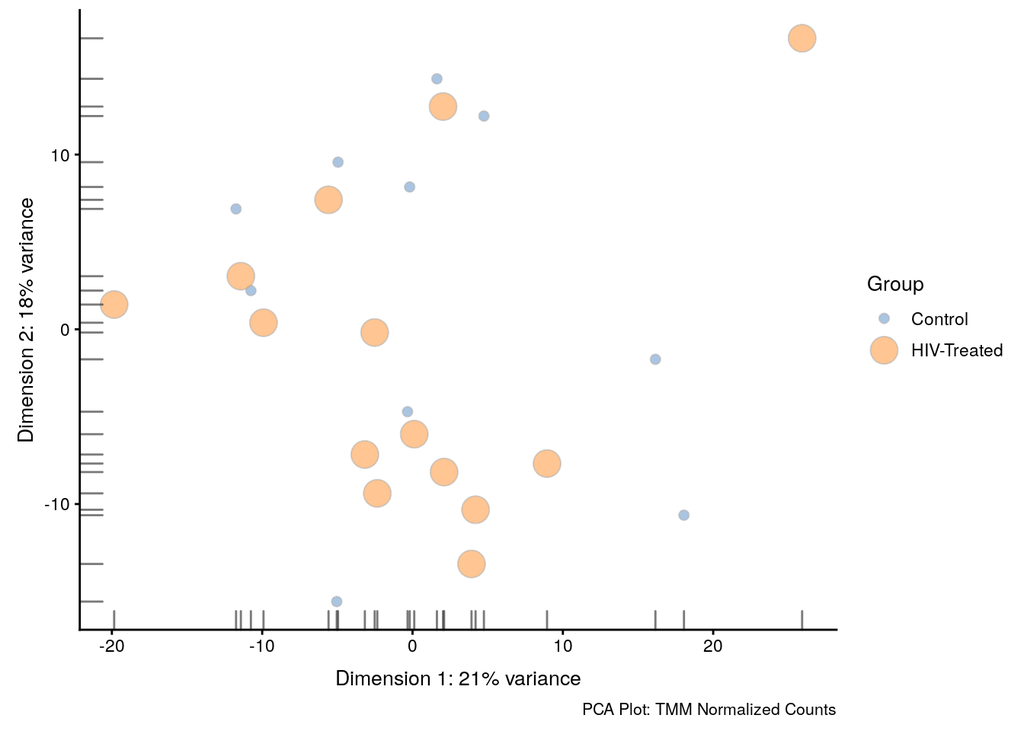

```r
# save TMM normalized counts
write.xlsx(merge(cnts.TMM.id, cnts_fsym[, 1:2], by = "Gene_ID"),
    "~/Documents/gitlab/Cario_RNASeq_Microbiom_Inte/DataProcessed/Summary/Treated/TMM_counts_HIVtreated.xlsx",
    sheetName = "TMM HIV treated")

## cnts. list all remains the sames other than cnts.edger
## since we will only use edger for downstream analysis
cnts.list <- list(cnts_f_dele, cnts.edger, cnts.deseq2, cnts.tpm)
cnts.names <- c("Filtered Counts", "TMM Normalized Counts", "DESeq2 Normalized Counts",
    "TPM Normalized Counts")
par(mfrow = c(1, 2))

rna_info <- data.frame(pid = rna.pid, Group = as.factor(c(rep("Control",
    10), rep("HIV-Treated", 14))))
rna_info$Group %<>% relevel("Control")
dir <- "~/Documents/gitlab/Cario_RNASeq_Microbiom_Inte/DataProcessed/Summary/Treated/plots/"
# qc plots
for (i in 2) {
    j = cnts.list[[i]]
    ## using scater, start with an object
    example_sce <- SingleCellExperiment(assays = list(counts = j),
        colData = rna_info)
    ## RLE plots
    print(scater::plotRLE(example_sce, exprs_values = "counts",
        exprs_logged = FALSE, colour_by = "Group", style = "minimal") +
        scale_x_discrete("Samples", labels = rna.pid) + labs(caption = paste("RLE Plot:",
        cnts.names[i])))
    ggsave(paste(dir, "RLE_plot.tiff", sep = ""), dpi = 300)
    ## pca plots
    example_sce <- SingleCellExperiment(assays = list(logcounts = j),
        colData = rna_info)
    print(scater::plotPCA(example_sce, colour_by = "Group", size_by = "Group") +
        labs(caption = paste("PCA Plot:", cnts.names[i])))
    ggsave(paste(dir, "PCA_plot.tiff", sep = ""), dpi = 300)
}
```

```r
############### DE analysis ######################## DE analysis of edger
y <- estimateDisp(y)
```

```
## Design matrix not provided. Switch to the classic mode.
```

```r
et <- exactTest(y, pair = 1:2)
dim(et)
```

```
## [1] 19454     3
```

```r
y$samples
```

```
##        group lib.size norm.factors
## Dys273     1  9911221    1.0330623
## Dys458     1 12864304    0.9738737
## TR1407     1 12343180    1.0147846
## TR1411     1 15397860    1.0058533
## TR1413     1  8250381    1.0496798
## TR1414     1 16792358    0.9601792
## TR1441     1 18627946    0.9338804
## TR1465     1 37806975    1.0210527
## TR1470     1 13606210    1.0069346
## TR1547     1 18822910    1.0698456
## TR1540     2 29118046    1.0564466
## TR1543     2 10517275    1.0222406
## TR1549     2 17635931    0.9404759
## TR1551     2  9410478    1.0009466
## TR1584     2 16426100    0.9980155
## TR1609     2 12676127    0.9435045
## TR1624     2  8479498    0.9507920
## TR1667     2 20695728    1.0316035
## TR1745     2 13343289    1.0603504
## TR1761     2 16905800    0.9963061
## TR1762     2 22614419    0.9684058
## TR1767     2 17213442    0.9743214
## TR1772     2 16863025    1.0200046
## TR1778     2 24971043    0.9852549
```

```r
### results
topTags(et, n = 10, adjust.method = "BH")
```

```
## Comparison of groups:  2-1
##                         logFC     logCPM       PValue         FDR
## ENSG00000231167.3  -3.0667632  2.7510100 1.729711e-08 0.000336498
## ENSG00000231918.1   3.1198785 -0.6834974 4.307519e-07 0.003267316
## ENSG00000163159.11 -0.5485205  4.1746992 5.038526e-07 0.003267316
## ENSG00000137312.14 -0.4348820  4.9841877 1.722027e-06 0.008375078
## ENSG00000264229.1  -1.2079349  4.7726974 2.218883e-06 0.008633230
## ENSG00000212464.1  -1.1789614  4.6955775 6.114123e-06 0.017797942
## ENSG00000141510.16 -0.4997218  4.3363469 7.597590e-06 0.017797942
## ENSG00000215184.2   0.6026287  4.5631669 8.042004e-06 0.017797942
## ENSG00000130731.15 -0.4849684  3.2376133 8.233858e-06 0.017797942
## ENSG00000090615.13  0.3440899  8.2220073 9.219197e-06 0.017935025
```

```r
head(et$table)
```

```
##                          logFC     logCPM    PValue
## ENSG00000148584.14  0.02833755  6.9490017 0.8537808
## ENSG00000175899.14  0.15826641  5.7406230 0.2682355
## ENSG00000256069.7  -0.22321331 -0.9915824 0.5117111
## ENSG00000128274.15  0.09850382  1.5012570 0.6115240
## ENSG00000094914.12 -0.01495534  2.4371195 0.9131733
## ENSG00000081760.16  0.14037314  5.6324790 0.2765483
```

```r
et$comparison
```

```
## [1] "1" "2"
```

```r
## summary results
summary(decideTests(et, p.value = 0.2, lfc = 0))
```

```
##          2-1
## Down      73
## NotSig 19333
## Up        48
```

```r
summary(decideTests(et, p.value = 0.1, lfc = 0))
```

```
##          2-1
## Down      34
## NotSig 19399
## Up        21
```

```r
summary(decideTests(et, p.value = 0.05, lfc = 0))
```

```
##          2-1
## Down      17
## NotSig 19428
## Up         9
```

```r
# paste(1706+ 2540, 'genes with FDR 0.05')

summary(decideTests(et, p.value = 0.05, lfc = 1))
```

```
##          2-1
## Down       4
## NotSig 19448
## Up         2
```

```r
# paste(157 + 680, 'genes with FDR 0.05')

summary(decideTests(et, p.value = 0.05, lfc = 2))
```

```
##          2-1
## Down       2
## NotSig 19451
## Up         1
```

```r
################# results ############# import genes lists
isgs <- as.data.frame(read.delim("~/Documents/gitlab/Cario_RNASeq_Microbiom_Inte/DataRaw/coreISG252"))
dim(isgs)
```

```
## [1] 252   2
```

```r
genesbeta <- as.data.frame(read.delim("~/Documents/gitlab/Cario_RNASeq_Microbiom_Inte/DataRaw/genesbeta424"))
dim(genesbeta)
```

```
## [1] 424   2
```

```r
sig_res <- as.data.frame(topTags(et, n = 30, adjust.method = "BH")[[1]])

sig_res_format <- sig_res %>% data.frame() %>% rownames_to_column("Gene_ID")

write.xlsx(sig_res_format, "~/Documents/gitlab/Cario_RNASeq_Microbiom_Inte/DataProcessed/Summary/Treated/DE_results_treated_005.xlsx",
    sheetName = "DE Results Treated")

# relax the cutoff to 0.05
merge(sig_res_format, isgs, by = "Gene_ID")
```

```
##              Gene_ID      logFC   logCPM       PValue        FDR Symbol
## 1 ENSG00000185201.16 -0.6864235 4.487527 8.248943e-05 0.05533618 IFITM2
```

```r
merge(sig_res_format, genesbeta, by = "Gene_ID")
```

```
## [1] Gene_ID logFC   logCPM  PValue  FDR     Symbol
## <0 rows> (or 0-length row.names)
```

```r
# relax the cutoff to 0.2
sig_res <- as.data.frame(topTags(et, n = 121, adjust.method = "BH")[[1]])

sig_res_format <- sig_res %>% data.frame() %>% rownames_to_column("Gene_ID")

results.isgs <- merge(sig_res_format, isgs, by = "Gene_ID")
results.isgs
```

```
##              Gene_ID      logFC   logCPM       PValue        FDR Symbol
## 1 ENSG00000185201.16 -0.6864235 4.487527 8.248943e-05 0.05533618 IFITM2
```

```r
write.xlsx(results.isgs, "~/Documents/gitlab/Cario_RNASeq_Microbiom_Inte/DataProcessed/Summary/Treated/DE_isgs_results_treated_02.xlsx",
    sheetName = "DE Results ISGS Treated")
results.genesbeta <- merge(sig_res_format, genesbeta, by = "Gene_ID")
results.genesbeta
```

```
##              Gene_ID     logFC   logCPM       PValue        FDR Symbol
## 1 ENSG00000074660.15 0.4600432 2.831500 0.0001968708 0.08667703 SCARF1
## 2  ENSG00000263956.6 0.5292614 3.362128 0.0010105753 0.18036451 NBPF11
```

```r
write.xlsx(results.genesbeta, "~/Documents/gitlab/Cario_RNASeq_Microbiom_Inte/DataProcessed/Summary/Treated/DE_genesbeta_results_treated_02.xlsx",
    sheetName = "DE Results Beta Treated")

results <- merge(sig_res_format, cnts_fsym[, c(1, 2)], by = "Gene_ID") %>%
    dplyr::select(-Gene_ID) %>% dplyr::select(Symbol, everything()) %>%
    dplyr::arrange(PValue) %>% dplyr::mutate(Direction = ifelse(logFC >
    0, "Up in HIV", "Down in HIV"))

results %>% kable
```

| Symbol | logFC | logCPM | PValue | FDR | Direction |
| --- | --- | --- | --- | --- | --- |
| YBX1P2 | -3.0667632 | 2.7510100 | 0.0000000 | 0.0003365 | Down in HIV |
| AC007682.1 | 3.1198785 | -0.6834974 | 0.0000004 | 0.0032673 | Up in HIV |
| VPS72 | -0.5485205 | 4.1746992 | 0.0000005 | 0.0032673 | Down in HIV |
| FLOT1 | -0.4348820 | 4.9841877 | 0.0000017 | 0.0083751 | Down in HIV |
| RNU4ATAC | -1.2079349 | 4.7726974 | 0.0000022 | 0.0086332 | Down in HIV |
| SNORA12 | -1.1789614 | 4.6955775 | 0.0000061 | 0.0177979 | Down in HIV |
| TP53 | -0.4997218 | 4.3363469 | 0.0000076 | 0.0177979 | Down in HIV |
| RP11-8L18.2 | 0.6026287 | 4.5631669 | 0.0000080 | 0.0177979 | Up in HIV |
| C16orf13 | -0.4849684 | 3.2376133 | 0.0000082 | 0.0177979 | Down in HIV |
| GOLGA3 | 0.3440899 | 8.2220073 | 0.0000092 | 0.0179350 | Up in HIV |
| SELENBP1 | -0.5942816 | 9.4302660 | 0.0000125 | 0.0215764 | Down in HIV |
| MAN2C1 | -0.6305849 | 3.0830834 | 0.0000134 | 0.0215764 | Down in HIV |
| RP11-329J18.3 | 0.5839970 | 2.0886666 | 0.0000144 | 0.0215764 | Up in HIV |
| CDC42SE1 | -0.4492613 | 3.9940948 | 0.0000219 | 0.0303925 | Down in HIV |
| RP11-1060J15.9 | 1.1317910 | 0.3796682 | 0.0000251 | 0.0318230 | Up in HIV |
| APEX1 | -0.3915839 | 5.9260783 | 0.0000262 | 0.0318230 | Down in HIV |
| RP11-290F24.6 | 0.6027664 | 4.5043664 | 0.0000311 | 0.0330471 | Up in HIV |
| MLLT6 | -0.4682565 | 6.5739010 | 0.0000327 | 0.0330471 | Down in HIV |
| UBE2Z | -0.2892145 | 6.6864291 | 0.0000330 | 0.0330471 | Down in HIV |
| HIST1H1E | -0.6937931 | 2.8995373 | 0.0000340 | 0.0330471 | Down in HIV |
| RP11-1060J15.5 | 0.8315369 | 2.8311392 | 0.0000382 | 0.0353929 | Up in HIV |
| RP11-159N11.4 | 0.9455975 | 0.5785401 | 0.0000405 | 0.0356044 | Up in HIV |
| ITPRIPL2 | -0.3980380 | 6.1363150 | 0.0000421 | 0.0356044 | Down in HIV |
| RP11-848P1.4 | -5.0855660 | -0.4676039 | 0.0000505 | 0.0409200 | Down in HIV |
| CCDC162P | 0.7550957 | 2.8970493 | 0.0000579 | 0.0450721 | Up in HIV |
| DHRS1 | -0.5554737 | 7.2387313 | 0.0000645 | 0.0482542 | Down in HIV |
| FLOT2 | -0.4906845 | 5.2280934 | 0.0000699 | 0.0503958 | Down in HIV |
| CTD-2373H9.3 | -1.1640019 | -0.5259021 | 0.0000755 | 0.0524878 | Down in HIV |
| IFITM2 | -0.6864235 | 4.4875275 | 0.0000825 | 0.0553362 | Down in HIV |
| ATF4 | 0.3131149 | 7.7741930 | 0.0000864 | 0.0560188 | Up in HIV |

[output cut: 91 more lines]